# Final_Supervised Final Notebook

### Modeling

To start building out the models, we split out the target variable 'is_canceled' with other features. We also divide up data into training (80%) and testing data set (20%) to validate our models.

```python
X, y = df.drop(['is_canceled'], axis =1), df['is_canceled']
```

```python
y
```

```
0         0
1         0
2         0
3         0
4         0
         ..
119385    0
119386    0
119387    0
119388    0
119389    0
Name: is_canceled, Length: 118902, dtype: int64
```

```python
train_X, test_X, train_y, test_y = train_test_split(X,y, train_size = 0.8, test_size =0.2)
```

#### Decision Tree

One of the model we built is the Decision Tree model from sklearn. To help us identify good parameters for the model, we used the GridSerachCV funciton to help us pick the best comination of the "criteriaon", "max_depth" and "min_samples_leaf" among the range of values we've chosen. We've use the GridSearch several times to find the best combination of parameter values, and then update the range accordingly to see if there are better values. Please see below for the last GridSearch we performed that yield satisfying parameters (measured by accuracy of the model).

```python
from sklearn.tree import DecisionTreeClassifier
from sklearn.model_selection import GridSearchCV
```

```python
dt = DecisionTreeClassifier()
```

```python
param_map = {
    'criterion':('gini', 'entropy'),
    "max_depth":[8,9,10,11],
    "min_samples_leaf":[0.01, 0.05,0.1]
}
```

```python
gs = GridSearchCV(dt, param_map,cv = 5, n_jobs = 4)
```

```python
gs.fit(train_X,train_y)
```

```
GridSearchCV(cv=5, estimator=DecisionTreeClassifier(), n_jobs=4,
             param_grid={'criterion': ('gini', 'entropy'),
                         'max_depth': [8, 9, 10, 11],
                         'min_samples_leaf': [0.01, 0.05, 0.1]})
```

```python
gs.best_params_
```

```
{'criterion': 'entropy', 'max_depth': 11, 'min_samples_leaf': 0.01}
```

```python
#Import DecisionTreeClassifier from sklearn.tree
from sklearn.tree import DecisionTreeClassifier

# Instantiate a DecisionTreeClassifier 'dt' with a maximum depth of 6
dt = DecisionTreeClassifier(criterion='entropy',
                            max_depth=10,
                            min_samples_leaf=0.01,
                            random_state=3)
# Fit dt to the training set
dt.fit(train_X, train_y)

# Predict test set labels
y_pred = dt.predict(test_X)
print(y_pred[0:5])
```

```
[0 0 0 0 0]
```

```python
# Import accuracy_score
from sklearn.metrics import accuracy_score

# Predict test set labels
y_pred = dt.predict(test_X)

# Compute test set accuracy
acc = accuracy_score(test_y, y_pred)
print("Test set accuracy of dt: {:.2f}".format(acc))
```

```
Test set accuracy of dt: 0.83
```

To make sure that our model doesn't have overfitting or underfitting issues, we then computed the accuracy score of the trainng data set as well as the cross validation scores. We got a training set accuracy score and cross validaition score of 83%. Since our testing, training and cross validation scores are all the same, it's a good indicator that we don't have overfitting or underfitting problems in our model.

```python
# Predict the labels of the training set
y_pred_train = dt.predict(train_X)

# Evaluate the training set RMSE of dt
acc_train = accuracy_score(train_y, y_pred_train)

# Print RMSE_train
print('Train set accuracy of dt: {:.2f}'.format(acc_train))
```

```
Train set accuracy of dt: 0.83
```

```python
from sklearn.model_selection import cross_validate
from sklearn.model_selection import cross_val_score
```

```python
cv_results = cross_validate(dt, train_X, train_y, cv=5)
cv_results['test_score']
```

```
array([0.82775296, 0.82501051, 0.82406434, 0.82748108, 0.82784903])
```

```python
f"Cross Valiation accuracy: {round(sum(cv_results['test_score'])/5,2)}"
```

```
'Cross Valiation accuracy: 0.83'
```

To take a closer look at the model performance, we print out the Confusion Matrix and the Accuracy, Precision and Recall scores. Precision which is stating that the of the cancelations the model predicted, 80% of them actually cancelled. Recall which is stating that model is 70% sensitive to predict cancellations from guests who actually cancelled.

```python
from sklearn import metrics
cnf_matrix = metrics.confusion_matrix(test_y, y_pred)
cnf_matrix
```

```
array([[13215,  1606],
       [ 2466,  6494]], dtype=int64)
```

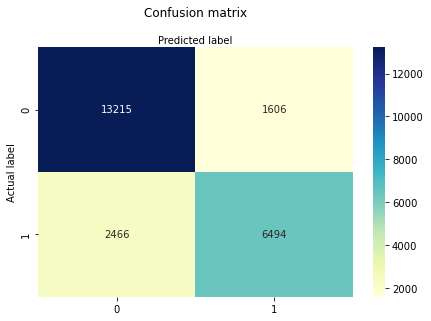

```python
class_names=[0,1] # name  of classes
fig, ax = plt.subplots()
tick_marks = np.arange(len(class_names))
plt.xticks(tick_marks, class_names)
plt.yticks(tick_marks, class_names)
# create heatmap
sns.heatmap(pd.DataFrame(cnf_matrix), annot=True, cmap="YlGnBu" ,fmt='g')
ax.xaxis.set_label_position("top")
plt.tight_layout()
plt.title('Confusion matrix', y=1.1)
plt.ylabel('Actual label')
plt.xlabel('Predicted label')
```

```python
print("Accuracy:",metrics.accuracy_score(test_y, y_pred))
print("Precision:",metrics.precision_score(test_y, y_pred))
print("Recall:",metrics.recall_score(test_y, y_pred))
```

```
Accuracy: 0.8287708674992641
Precision: 0.8017283950617284
Recall: 0.7247767857142857
```

Receiver Operating Characteristic(ROC) curve is a plot of the true positive rate against the false positive rate. It shows the tradeoff between sensitivity and specificity. 1 is good, perfect classification. 0.5 is worthless.

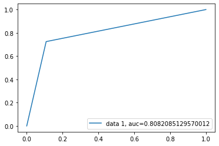

```python
fpr, tpr, _ = metrics.roc_curve(test_y,  y_pred)
auc = metrics.roc_auc_score(test_y,  y_pred)
plt.plot(fpr,tpr,label="data 1, auc="+str(auc))
plt.legend(loc=4)
plt.show()
```

For Decision Tree Models we can also understand the feature imporatnces of all our features. It looks like the most importart feature by large is the deposit_type which agrees our intuition that if a guest put down deposit he or she is less likely to cancel the hotel room.

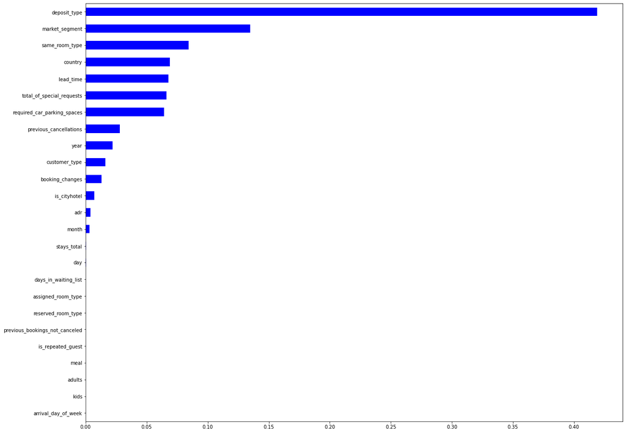

```python
# Create a pd.Series of features importances
importances_dt = pd.Series(dt.feature_importances_,
index = X.columns)
# Sort importances_rf
sorted_importances_dt = importances_dt.sort_values()
# Make a horizontal bar plot
sorted_importances_dt.plot(kind='barh', color='blue',figsize=(20,16))
plt.show()
```

We could also see the nodes and leafs of the Decision Tree to understand the detailed classificaiton steps it took.

```python
from sklearn.tree import export_text

r = export_text(dt, feature_names=list(X.columns))
print(r)
```

```
|--- deposit_type <= 0.50
|   |--- same_room_type <= 0.50
|   |   |--- country <= 134.50
|   |   |   |--- market_segment <= 5.50
|   |   |   |   |--- lead_time <= 98.50
|   |   |   |   |   |--- market_segment <= 4.50
|   |   |   |   |   |   |--- class: 0
|   |   |   |   |   |--- market_segment >  4.50
|   |   |   |   |   |   |--- class: 0
|   |   |   |   |--- lead_time >  98.50
|   |   |   |   |   |--- class: 0
|   |   |   |--- market_segment >  5.50
|   |   |   |   |--- lead_time <= 16.50
|   |   |   |   |   |--- class: 0
|   |   |   |   |--- lead_time >  16.50
|   |   |   |   |   |--- class: 0
|   |   |--- country >  134.50
|   |   |   |--- lead_time <= 69.50
|   |   |   |   |--- total_of_special_requests <= 0.50
|   |   |   |   |   |--- adr <= 45.50
|   |   |   |   |   |   |--- class: 0
|   |   |   |   |   |--- adr >  45.50
|   |   |   |   |   |   |--- class: 0
|   |   |   |   |--- total_of_special_requests >  0.50
|   |   |   |   |   |--- class: 0
|   |   |   |--- lead_time >  69.50
|   |   |   |   |--- class: 0
|   |--- same_room_type >  0.50
|   |   |--- required_car_parking_spaces <= 0.50
|   |   |   |--- lead_time <= 8.50
|   |   |   |   |--- country <= 134.50
|   |   |   |   |   |--- market_segment <= 5.50
|   |   |   |   |   |   |--- country <= 51.50
|   |   |   |   |   |   |   |--- class: 0
|   |   |   |   |   |   |--- country >  51.50
|   |   |   |   |   |   |   |--- class: 0
|   |   |   |   |   |--- market_segment >  5.50
|   |   |   |   |   |   |--- total_of_special_requests <= 0.50
|   |   |   |   |   |   |   |--- class: 0
|   |   |   |   |   |   |--- total_of_special_requests >  0.50
```

[output cut: 93 more lines]

```
|   |   |   |   |   |   |   |   |--- class: 0
|   |   |   |   |   |   |   |--- customer_type >  2.50
|   |   |   |   |   |   |   |   |--- class: 0
|   |   |   |   |   |--- previous_cancellations >  0.50
|   |   |   |   |   |   |--- class: 1
|   |   |--- required_car_parking_spaces >  0.50
|   |   |   |--- class: 0
|--- deposit_type >  0.50
|   |--- customer_type <= 2.50
|   |   |--- lead_time <= 53.50
|   |   |   |--- class: 1
|   |   |--- lead_time >  53.50
|   |   |   |--- class: 1
|   |--- customer_type >  2.50
|   |   |--- class: 1
```

#### Random Forest

Another model we built is the Random Forest model from sklearn. To help us identify good parameters for the model, we used the GridSerachCV function to help us pick the best comination of the "max_depth" and "min_samples_leaf" among the range of values we've chosen. We've use the GridSearch several times to find the best combination of parameter values, and then update the range accordingly to see if there are better values. Please see below for the last GridSearch we performed that yield satisfying parameters (measured by accuracy of the model).

```python
from sklearn.ensemble import RandomForestClassifier
rf=RandomForestClassifier()
```

```python
param_map = {
    "max_depth":[9,10,11],
    "min_samples_leaf":[0.01,0.05,0.1]
}
```

```python
gs = GridSearchCV(rf, param_map,cv = 5, n_jobs = 4)
```

```python
gs.fit(train_X,train_y)
```

```
GridSearchCV(cv=5, estimator=RandomForestClassifier(), n_jobs=4,
             param_grid={'max_depth': [9, 10, 11],
                         'min_samples_leaf': [0.01, 0.05, 0.1]})
```

```python
gs.best_params_
```

```
{'max_depth': 11, 'min_samples_leaf': 0.01}
```

After we've decide on the model parameters, we use the RandomForestClassifier to fit our training data set. After that, we use the model to predict the label using the features in out testing data set and computed the accuracy score by comparing to the actual labels of the testing data set. In our case, we've obtained an accuracy score of 83%.

To make sure that our model doesn't have overfitting or underfitting issues, we then computed the accuracy score of the trainng data set as well as the cross validation scores. We got a training set accuracy score of 82% and cross validaition score of 82%. Since our testing, training and cross validation scores are the same, it's a good indicator that we don't have overfitting or underfitting problems in our model.

```python
from sklearn.ensemble import RandomForestClassifier

# Set seed for reproducibility
SEED = 1

# Instantiate a random forests regressor 'rf' 400 estimators
rf = RandomForestClassifier(n_estimators=400,
                            max_depth= 11,
                            min_samples_leaf=0.01,
                            random_state=SEED)

# Fit 'rf' to the training set
rf.fit(train_X, train_y)

# Predict the test set labels 'y_pred'
y_pred = rf.predict(test_X)
y_pred_train=rf.predict(train_X)

# Evaluate the test set RMSE
acc_test = accuracy_score(test_y, y_pred)
acc_train = accuracy_score(train_y, y_pred_train)

# Print the test set RMSE
print('Test set accuracy of rf: {:.2f}'.format(acc_test))
print('Train set accuracy of rf: {:.2f}'.format(acc_train))
```

```
Test set accuracy of rf: 0.83
Train set accuracy of rf: 0.82
```

```python
cv_results = cross_validate(rf, train_X, train_y, cv=5)
cv_results['test_score']
```

```
array([0.82281209, 0.82527334, 0.82296047, 0.82637721, 0.81954373])
```

```python
f"Cross Valiation accuracy: {round(sum(cv_results['test_score'])/5,2)}"
```

```
'Cross Valiation accuracy: 0.82'
```

To take a closer look at the model performance, we print out the Confusion Matrix and the Accuracy, Precision and Recall scores. Precision which is stating that the of the cancelations the model predicted, 88% of them actually cancelled. Recall which is stating that model is 60% sensitive to predict cancellations from guests who actually cancelled. While the Precision score of the Random Forest is higher than the Decision Tree, the Recall score is lower.

```python
from sklearn import metrics
cnf_matrix = metrics.confusion_matrix(test_y, y_pred)
cnf_matrix
```

```
array([[14137,   684],
       [ 3446,  5514]], dtype=int64)
```

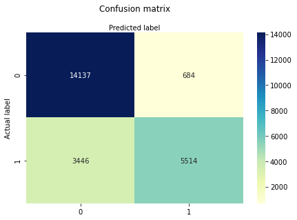

```python
class_names=[0,1] # name  of classes
fig, ax = plt.subplots()
tick_marks = np.arange(len(class_names))
plt.xticks(tick_marks, class_names)
plt.yticks(tick_marks, class_names)
# create heatmap
sns.heatmap(pd.DataFrame(cnf_matrix), annot=True, cmap="YlGnBu" ,fmt='g')
ax.xaxis.set_label_position("top")
plt.tight_layout()
plt.title('Confusion matrix', y=1.1)
plt.ylabel('Actual label')
plt.xlabel('Predicted label')
```

```python
print("Accuracy:",metrics.accuracy_score(test_y, y_pred))
print("Precision:",metrics.precision_score(test_y, y_pred))
print("Recall:",metrics.recall_score(test_y, y_pred))
```

```
Accuracy: 0.8263319456709137
Precision: 0.8896418199419167
Recall: 0.6154017857142857
```

Receiver Operating Characteristic(ROC) curve is a plot of the true positive rate against the false positive rate. It shows the tradeoff between sensitivity and specificity. 1 is good, perfect classification. 0.5 is worthless.

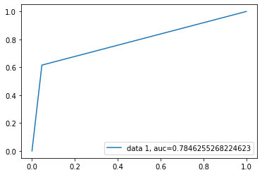

```python
fpr, tpr, _ = metrics.roc_curve(test_y,  y_pred)
auc = metrics.roc_auc_score(test_y,  y_pred)
plt.plot(fpr,tpr,label="data 1, auc="+str(auc))
plt.legend(loc=4)
plt.show()
```

For RandomForest Models we can also understand the feature imporatnces of all our features. It looks like the most importart feature by large is the deposit_type which agrees our intuition that if a guest put down deposit he or she is less likely to cancel the hotel room.

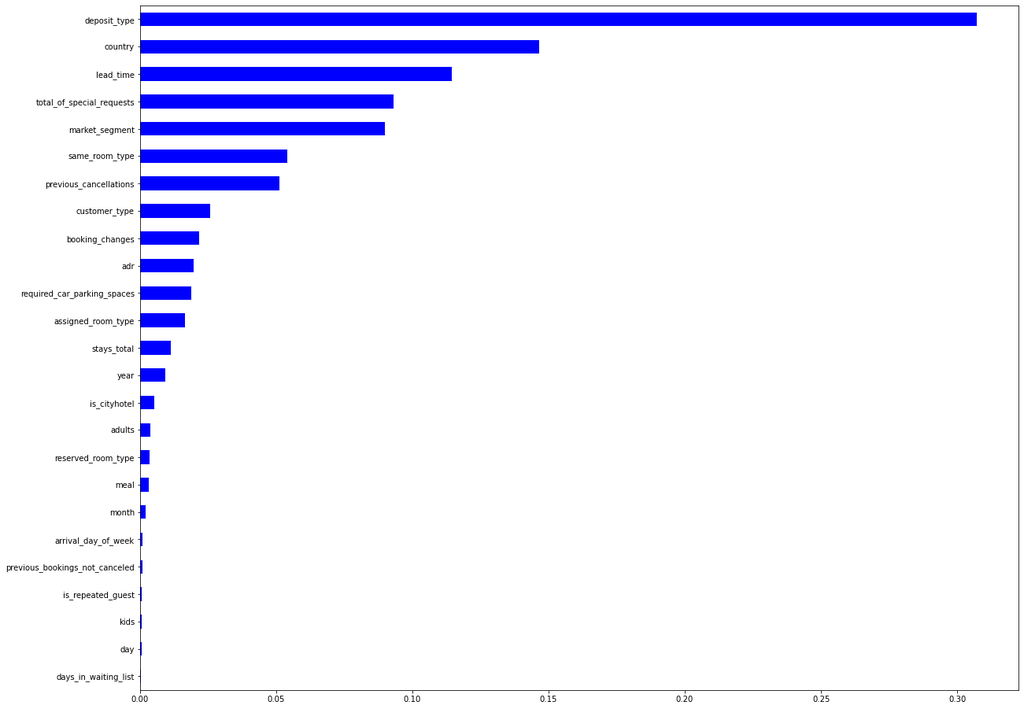

```python
# Create a pd.Series of features importances
importances_rf = pd.Series(rf.feature_importances_,
index = X.columns)
# Sort importances_rf
sorted_importances_rf = importances_rf.sort_values()
# Make a horizontal bar plot
sorted_importances_rf.plot(kind='barh', color='blue',figsize=(20,16))
plt.show()
```

### Logistics Regression

```python
from sklearn.linear_model import LogisticRegression

logReg=LogisticRegression(solver='lbfgs', max_iter=5000)

logReg.fit(train_X, train_y)

y_pred = logReg.predict(test_X)
```

Increased max_iter because there was a convergance warning.

```python
# Import accuracy_score
from sklearn.metrics import accuracy_score

# Predict test set labels
y_pred = logReg.predict(test_X)

# Compute test set accuracy
acc = accuracy_score(test_y, y_pred)
print("Test set accuracy of Log: {:.2f}".format(acc))
```

```
Test set accuracy of Log: 0.79
```

```python
# Predict the labels of the training set
y_pred_train = logReg.predict(train_X)

# Evaluate the training set RMSE of dt
acc_train = accuracy_score(train_y, y_pred_train)

# Print RMSE_train
print('Train set accuracy of Log: {:.2f}'.format(acc_train))
```

```
Train set accuracy of Log: 0.79
```

```python
import warnings
warnings.filterwarnings("ignore")
cv_results = cross_validate(logReg, train_X, train_y, cv=5)
cv_results['test_score']
```

```
array([0.79406045, 0.78863541, 0.79231497, 0.79578427, 0.79278806])
```

```python
f"Cross Valiation accuracy: {round(sum(cv_results['test_score'])/5,2)}"
```

```
'Cross Valiation accuracy: 0.79'
```

```python
from sklearn import metrics
cnf_matrix = metrics.confusion_matrix(test_y, y_pred)
cnf_matrix
```

```
array([[13691,  1130],
       [ 3782,  5178]], dtype=int64)
```

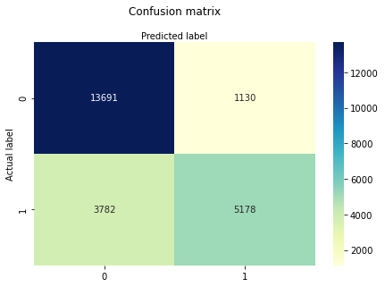

```python
class_names=[0,1] # name  of classes
fig, ax = plt.subplots()
tick_marks = np.arange(len(class_names))
plt.xticks(tick_marks, class_names)
plt.yticks(tick_marks, class_names)
# create heatmap
sns.heatmap(pd.DataFrame(cnf_matrix), annot=True, cmap="YlGnBu" ,fmt='g')
ax.xaxis.set_label_position("top")
plt.tight_layout()
plt.title('Confusion matrix', y=1.1)
plt.ylabel('Actual label')
plt.xlabel('Predicted label')
```

```python
print("Accuracy:",metrics.accuracy_score(test_y, y_pred))
print("Precision:",metrics.precision_score(test_y, y_pred))
print("Recall:",metrics.recall_score(test_y, y_pred))
```

```
Accuracy: 0.7934485513645347
Precision: 0.8208623969562461
Recall: 0.5779017857142857
```

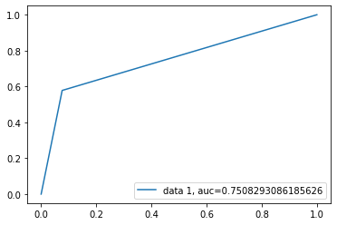

```python
fpr, tpr, _ = metrics.roc_curve(test_y,  y_pred)
auc = metrics.roc_auc_score(test_y,  y_pred)
plt.plot(fpr,tpr,label="data 1, auc="+str(auc))
plt.legend(loc=4)
plt.show()
```

```python
Log_importance = logReg.coef_[0]
Log_importance
```

```
array([ 2.84605348e-03, -3.20238159e-03, -7.33378039e-04,  1.34966394e-01,
       -1.91874225e-02,  1.09498898e-02,  4.32191362e-01, -4.94776077e-01,
        2.30270378e+00, -3.32892382e-01,  1.71164284e-02, -4.70844293e-02,
       -3.66785411e-01,  4.27721864e+00, -3.70208374e-03, -7.85848319e-02,
        5.57446281e-03, -3.70822082e+00, -5.85938412e-01, -1.64947923e-02,
        3.95037787e-02,  1.55423378e-01,  1.89395612e+00,  7.47914093e-02,
        1.98826480e-02])
```

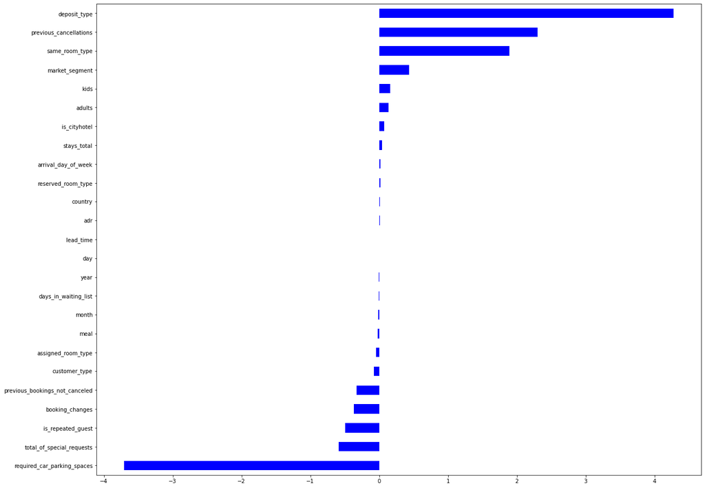

```python
# Create a pd.Series of features importances
importances_log = pd.Series(Log_importance,
index = X.columns)
# Sort importances
sorted_importances_log = importances_log.sort_values()
# Make a horizontal bar plot
sorted_importances_log.plot(kind='barh', color='blue',figsize=(20,16))
plt.show()
```

Logistics Regression is an easy model to implement, doesn’t require too many computational resources and any tuning. However, there are some questionable results from the model based on the coefficients importance selection. There are many features (like repeat guests and previous booking not cancelled) that seem important for accurately predicting cancellations are coming out as negative features. In hypothetical scenario where if we were just modeling with Logistics Regression, one option is to drop the negative features and rerun the model. However, we would end up with few features in our model which would create a poor fit. Logistics Regressions has multiple setbacks, especially for our hotel cancellations predictions project.

First, Logistic Regression requires moderate or no multicollinearity between our features (independent variables). Second, on high dimensional datasets, which is likely the case in real world application of our project, this may lead to the model being over-fit on the training set, which means overstating the accuracy of predictions on the training set and thus the model may not be able to predict accurate results on the test set.

Overall, the model doesn't seem satisfactory which is why we have to try other options like CatBoost.

### CatBoost

An alternative model to use instead is CatBoost. CatBoost is model that is based on gradient boosted decision trees. A set of decision trees is built consecutively during training where each successive tree is built with reduced loss compared to the previous trees.

Before the models go into the learning phase, the models create feature-split pairs for all features. Catboost uses Minimal Variance Sampling (MVS) for splits where weighted sampling happens in the tree-level and not in the split level. The observations for each boosting tree are sampled in a way that maximizes the accuracy of split scoring. This makes CatBoost faster than a model like XGBoost where there is no weighted sampling technique.

With regards to leaf growth, Catboost grows a balanced tree. In each level of the tree, the feature-split pair that brings to the smallest loss is selected and is used for all the level’s nodes. Another thing to keep in mind is that CatBoost has automatic categorical feature handling where it uses a combination of one-hot encoding and an advanced mean encoding. However, we didn't utilize this feature here because we already used an encoder for our data.

```python
#conda config --add channels conda-forge
```

```python
#conda install catboost
```

```python
from catboost import CatBoostClassifier
model_cb = CatBoostClassifier()
model_cb.fit(train_X, train_y)
```

[output not shown]

[output cut: 946 more lines]

[output not shown]

```
<catboost.core.CatBoostClassifier at 0x2315547ec88>
```

```python
# Import accuracy_score
from sklearn.metrics import accuracy_score

# Predict test set labels
y_pred = model_cb.predict(test_X)

# Compute test set accuracy
acc = accuracy_score(test_y, y_pred)
print("Test set accuracy of CatBoost: {:.2f}".format(acc))
```

```
Test set accuracy of CatBoost: 0.88
```

```python
# Predict the labels of the training set
y_pred_train = model_cb.predict(train_X)

# Evaluate the training set RMSE of dt
acc_train = accuracy_score(train_y, y_pred_train)

# Print RMSE_train
print('Train set accuracy of CatBoost: {:.2f}'.format(acc_train))
```

```
Train set accuracy of CatBoost: 0.89
```

```python
cv_results = cross_validate(model_cb, train_X, train_y, cv=5)
cv_results['test_score']
```

[output not shown]

[output cut: 4950 more lines]

[output not shown]

```
array([0.87742444, 0.8727397 , 0.8739487 , 0.87326535, 0.87594617])
```

```python
f"Cross Valiation accuracy: {round(sum(cv_results['test_score'])/5,2)}"
```

```
'Cross Valiation accuracy: 0.87'
```

#### I didn't find it necessary to use GridSearchCV to find hyperparameters because the difference between CV, train and test accuracy is very small that I don't believe it calls for overfitting. If there was notable overfitting in the model, I would have ran GridSearchCV to tune the parameters to reduce the overfitting.

```python
from sklearn import metrics
cnf_matrix = metrics.confusion_matrix(test_y, y_pred)
cnf_matrix
```

```
array([[13712,  1109],
       [ 1788,  7172]], dtype=int64)
```

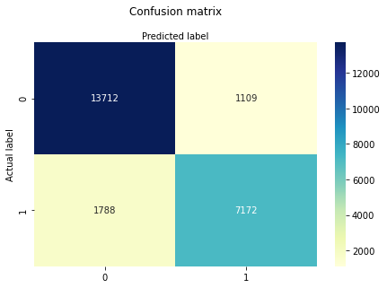

```python
class_names=[0,1] # name  of classes
fig, ax = plt.subplots()
tick_marks = np.arange(len(class_names))
plt.xticks(tick_marks, class_names)
plt.yticks(tick_marks, class_names)
# create heatmap
sns.heatmap(pd.DataFrame(cnf_matrix), annot=True, cmap="YlGnBu" ,fmt='g')
ax.xaxis.set_label_position("top")
plt.tight_layout()
plt.title('Confusion matrix', y=1.1)
plt.ylabel('Actual label')
plt.xlabel('Predicted label')
```

```python
print("Accuracy:",metrics.accuracy_score(test_y, y_pred))
print("Precision:",metrics.precision_score(test_y, y_pred))
print("Recall:",metrics.recall_score(test_y, y_pred))
```

```
Accuracy: 0.8781800597115345
Precision: 0.8660789759690859
Recall: 0.8004464285714286
```

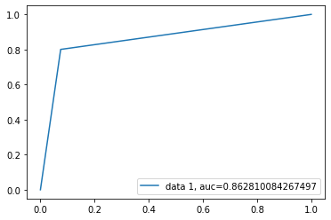

```python
fpr, tpr, _ = metrics.roc_curve(test_y,  y_pred)
auc = metrics.roc_auc_score(test_y,  y_pred)
plt.plot(fpr,tpr,label="data 1, auc="+str(auc))
plt.legend(loc=4)
plt.show()
```

An excellent model has AUC near to the 1 which means it has a good measure of separability. A poor model has AUC near to the 0 which means it has the worst measure of separability. In this case, the AUC is 0.86 which is relatively high.

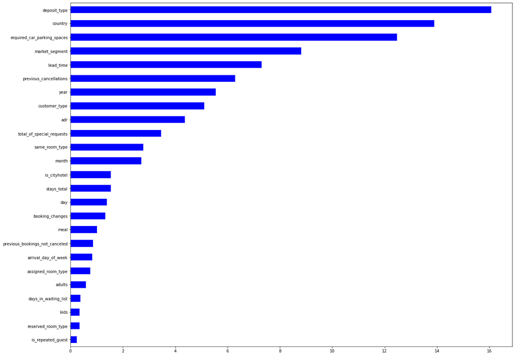

```python
# Create a pd.Series of features importances
importances_rf = pd.Series(model_cb.feature_importances_,
index = X.columns)
# Sort importances_rf
sorted_importances_rf = importances_rf.sort_values()
# Make a horizontal bar plot
sorted_importances_rf.plot(kind='barh', color='blue',figsize=(20,16))
plt.show()
```

We can see from the feature importance plot that deposit type and country are the two most important features. We got similar results from other models. A better option than just an importance feature plot is SHAP value plot.

### SHAP Value Plot

The SHAP value plot can further show the positive and negative relationships of the predictors with the target variable. What SHAP does is quantifying the contribution that each feature brings to the prediction made by the model. The difference between importance features and SHAP value plot is that SHAP not only shows the important features, but also shows the positive or negative impact for each variable on the target variable.

```python
#conda install -c conda-forge shap
```

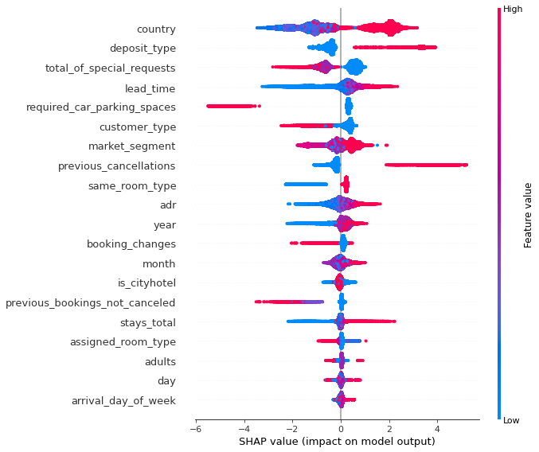

```python
import shap
shap_values = shap.TreeExplainer(model_cb).shap_values(train_X)
shap.summary_plot(shap_values, train_X)
```

The country of origin of the person who made the reservation has a high impact on cancellations. We see that if a specific country's value is high then there's high probability of reservation being cancelled. Depending on the country, the chances of a reservation being cancelled is the highest among other features. We did see in EDA that Portugal has a high number of reservations, so many of these values could be from Portugal. However, this result has to be interpreted with caution because in real life, we don't always have the nationality of the person until they check in to the hotel. In addition, there is a possibility that hotels use default values for the country if that is not provided. Thus, this can cause an impact on the model because we'd be modeling with inaccurate data.

Other important observations from this plot include total special requests. We see that when a Client does not make any special request the higher the probability that the customer will cancel. In addition, we also see that the higher the number of previous cancellations, the more likely is a customer to cancel a reservation (we can see the opposite with previous cancellations). Finally, the lower the lead time the lower the probability that a customer cancels their reservation.

The same concept applies for other features. One thing that can be done to improve the visualization of the country feature is to model around the data of one country such as Portugal and see what the outcome would be for the plot.

### Gradient Boost

```python
#conda install -c anaconda py-xgboost
```

Another model we built is Gradient Boost from sklearn. Gradient Boost is widely used in the data science world. To help us identify the best parameters for the model, we used the RandomizedSearchCV funciton to help us pick the best comination of 'max_depth', 'max_features','n_estimators', 'min_samples_split', 'min_samples_leaf', and 'learning_rate' among the lists of values we've chosen. We used the RandomizedSearch several times to find the best combination of parameter values, and then update the range accordingly to see if there are better values. Please see below for the lastest RandomizedSearch we performed that yield satisfying parameters (measured by accuracy of the model).

```python
from sklearn.ensemble import GradientBoostingClassifier
from sklearn.model_selection import GridSearchCV
from sklearn.model_selection import RandomizedSearchCV
from xgboost import XGBClassifier
```

```python
# Number of features to consider at every split
n_estimators = [int(x) for x in np.linspace(10, 30, num = 1)]

# learning rate options
learning_rate = [0.1,0.01,1,0.5]

# Minimum number of samples required to split a node
min_samples_split = [int(x) for x in np.linspace(2, 20, num = 20)]

# Minimum number of samples required at each leaf node
min_samples_leaf = [int(x) for x in np.linspace(1, 20, num = 20)]

# Maximum of features
max_features = [int(x) for x in np.linspace(1, 15, num = 15)]

# Maximum depth of a tree
max_depth = [int(x) for x in np.linspace(1, 10, num = 10)]

# Create the GB grid
gb_grid = {'n_estimators': n_estimators,
           'learning_rate': learning_rate,
           'min_samples_split': min_samples_split,
           'min_samples_leaf': min_samples_leaf,
           'max_features': max_features,
           'max_depth': max_depth}

# Use the gb grid to search for best hyperparameters
# First create the base model to tune
gb = GradientBoostingClassifier()

# Random search of parameters, using 5 fold cross validation,
# search across 100 different combinations, and use all available cores
gb_random = RandomizedSearchCV(estimator = gb, param_distributions = gb_grid, n_iter = 100, cv = 5, verbose=0,scoring='accuracy',
random_state=SEED, n_jobs = -1)

# Fit the random search model
gb_random.fit(train_X, train_y)
```

```
RandomizedSearchCV(cv=5, estimator=GradientBoostingClassifier(), n_iter=100,
                   n_jobs=-1,
                   param_distributions={'learning_rate': [0.1, 0.01, 1, 0.5],
                                        'max_depth': [1, 2, 3, 4, 5, 6, 7, 8, 9,
                                                      10],
                                        'max_features': [1, 2, 3, 4, 5, 6, 7, 8,
                                                         9, 10, 11, 12, 13, 14,
                                                         15],
                                        'min_samples_leaf': [1, 2, 3, 4, 5, 6,
                                                             7, 8, 9, 10, 11,
                                                             12, 13, 14, 15, 16,
                                                             17, 18, 19, 20],
                                        'min_samples_split': [2, 2, 3, 4, 5, 6,
                                                              7, 8, 9, 10, 11,
                                                              12, 13, 14, 15,
                                                              16, 17, 18, 19,
                                                              20],
                                        'n_estimators': [10]},
                   random_state=1, scoring='accuracy')
```

```python
gb_random.best_params_
```

```
{'n_estimators': 10,
 'min_samples_split': 12,
 'min_samples_leaf': 4,
 'max_features': 13,
 'max_depth': 10,
 'learning_rate': 0.5}
```

```python
#Fit GB Classifer
gb = GradientBoostingClassifier(n_estimators=10, learning_rate=.5, min_samples_split=12,
                               min_samples_leaf=4, max_features=13, max_depth=10, random_state=SEED)

# using best parameters when scoring = recall
#gb = GradientBoostingClassifier(n_estimators=10, learning_rate=.1, min_samples_split=8,
#                                min_samples_leaf=16, max_features=15, max_depth=10, random_state=SEED)

gb.fit(train_X,train_y)
```

```
GradientBoostingClassifier(learning_rate=0.5, max_depth=10, max_features=13,
                           min_samples_leaf=4, min_samples_split=12,
                           n_estimators=10, random_state=1)
```

```python
# Import accuracy_score
from sklearn.metrics import accuracy_score

# Predict test set labels
y_pred_gb = gb.predict(test_X)

# Compute test set accuracy
acc = accuracy_score(test_y, y_pred_gb)
print("Test set accuracy of GBM: {:.5f}".format(acc))
```

```
Test set accuracy of GBM: 0.86603
```

```python
# Predict the labels of the training set
y_pred_train_gb = gb.predict(train_X)

# Evaluate the training set RMSE of dt
acc_train = accuracy_score(train_y, y_pred_train_gb)

# Print RMSE_train
print('Train set accuracy of GBM: {:.5f}'.format(acc_train))
```

```
Train set accuracy of GBM: 0.88077
```

```python
# calculate CV accuracy score
Accuracy_CV_scores = cross_val_score(gb, train_X, train_y, cv=5,
                                     scoring='accuracy',
                                     n_jobs=-1)

print("GBM Accuracy score (CV): {0:.5f}".format(Accuracy_CV_scores.mean()))
```

```
GBM Accuracy score (CV): 0.86515
```

```python
# print the confusion matrix
from sklearn import metrics
cnf_matrix = metrics.confusion_matrix(test_y, y_pred_gb)
cnf_matrix
```

```
array([[13588,  1233],
       [ 1953,  7007]], dtype=int64)
```

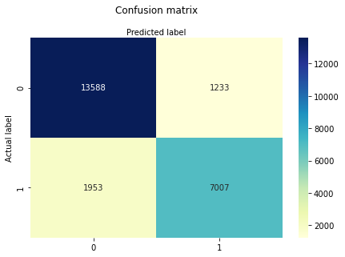

```python
# plot the confusion matrix
class_names=[0,1] # name  of classes
fig, ax = plt.subplots()
tick_marks = np.arange(len(class_names))
plt.xticks(tick_marks, class_names)
plt.yticks(tick_marks, class_names)
# create heatmap
sns.heatmap(pd.DataFrame(cnf_matrix), annot=True, cmap="YlGnBu" ,fmt='g')
ax.xaxis.set_label_position("top")
plt.tight_layout()
plt.title('Confusion matrix', y=1.1)
plt.ylabel('Actual label')
plt.xlabel('Predicted label')
```

```python
print("Accuracy:",metrics.accuracy_score(test_y, y_pred_gb))
print("Precision:",metrics.precision_score(test_y, y_pred_gb))
print("Recall:",metrics.recall_score(test_y, y_pred_gb))
```

```
Accuracy: 0.8660275009461335
Precision: 0.850364077669903
Recall: 0.78203125
```

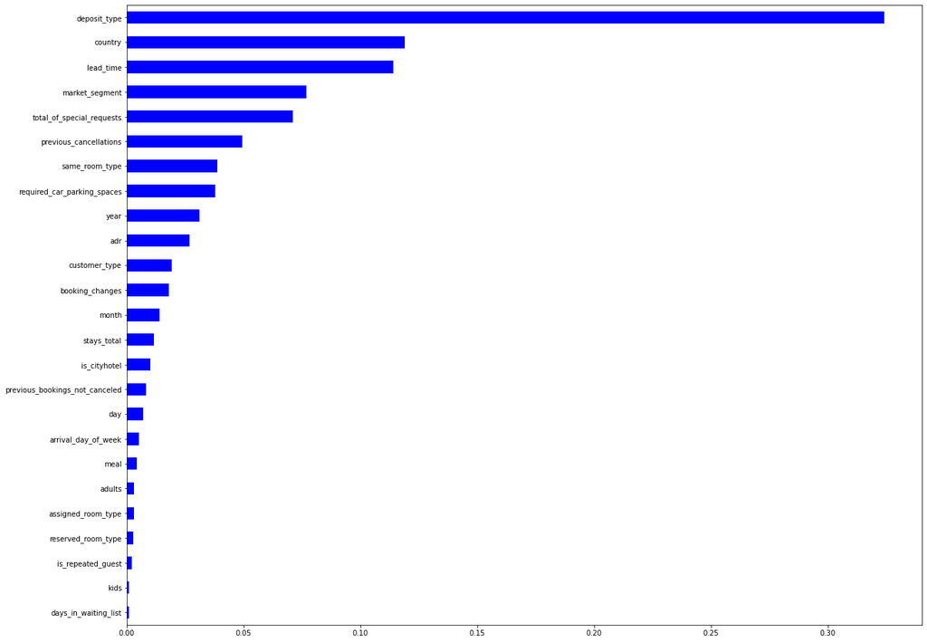

```python
# Create a pd.Series of features importances
importances_gb = pd.Series(gb.feature_importances_,
index = X.columns)
# Sort importances_gb
sorted_importances_gb = importances_gb.sort_values()
# Make a horizontal bar plot
sorted_importances_gb.plot(kind='barh', color='blue',figsize=(20,16))
plt.show()
```

```python
# another way of ploting feature importance
gb_feature_importances = pd.DataFrame(list(zip(train_X.columns.values, gb.feature_importances_)),
                                       columns =['Feafure', 'Importance'])
gb_feature_importances=gb_feature_importances.sort_values(by=['Importance'], ascending=False)
```

```python
gb_feature_importances
```

|  | Feafure | Importance |
| --- | --- | --- |
| 13 | deposit_type | 0.324164 |
| 5 | country | 0.119052 |
| 0 | lead_time | 0.114035 |
| 6 | market_segment | 0.076958 |
| 18 | total_of_special_requests | 0.070998 |
| 8 | previous_cancellations | 0.049424 |
| 22 | same_room_type | 0.038899 |
| 17 | required_car_parking_spaces | 0.037750 |
| 1 | year | 0.031155 |
| 16 | adr | 0.026901 |
| 15 | customer_type | 0.019095 |
| 12 | booking_changes | 0.018075 |
| 19 | month | 0.014132 |
| 20 | stays_total | 0.011536 |
| 23 | is_cityhotel | 0.009989 |
| 9 | previous_bookings_not_canceled | 0.008292 |
| 2 | day | 0.007174 |
| 24 | arrival_day_of_week | 0.005136 |
| 4 | meal | 0.004248 |
| 3 | adults | 0.003162 |
| 11 | assigned_room_type | 0.003001 |
| 10 | reserved_room_type | 0.002735 |
| 7 | is_repeated_guest | 0.002205 |
| 21 | kids | 0.000987 |
| 14 | days_in_waiting_list | 0.000897 |

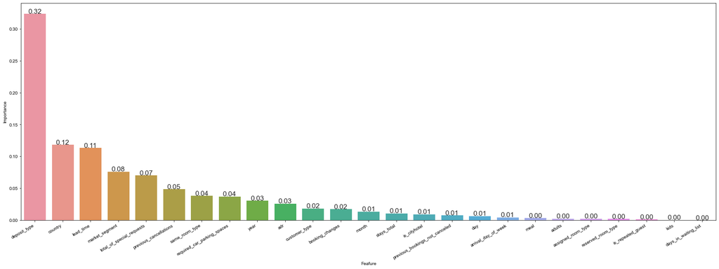

```python
# method 2 of plotting feature importance. This only acts as an alternative to put on the presentation slides
fig, ax = plt.subplots()
fig.set_size_inches(28, 10)
sns.set(font_scale = 1.3)
gbfi = sns.barplot(x="Feafure", y="Importance", data=gb_feature_importances)
fig.autofmt_xdate()

from matplotlib import pyplot as plt
import numpy as np

def show_values_on_bars(axs):
    def _show_on_single_plot(ax):
        for p in ax.patches:
            _x = p.get_x() + p.get_width() / 2
            _y = p.get_y() + p.get_height()
            value = '{:.2f}'.format(p.get_height())
            ax.text(_x, _y, value, ha="center")

    if isinstance(axs, np.ndarray):
        for idx, ax in np.ndenumerate(axs):
            _show_on_single_plot(ax)
    else:
        _show_on_single_plot(axs)

show_values_on_bars(gbfi)
```

### XG Boost

```python
# Gamma, the larger the more conervative
gamma = [0.01,0.1,0.5,1,2,3,5,10]

# Maximum number of levels in tree
max_depth = [int(x) for x in np.linspace(1, 10, num = 10)]

# Minimum sum of instance weight (hessian) needed in a child.
min_child_weight = [int(x) for x in np.linspace(1, 10, num = 10)]

# Subsample ratio of the training instances.
subsample = [float(x) for x in np.linspace(0.1, 1, num = 10)]

# Subsample ratio of columns when constructing each tree
colsample_bytree = [float(x) for x in np.linspace(0.1, 1, num = 10)]

# Create the XGB grid
xgb_grid = {'gamma': gamma,
            'max_depth': max_depth,
            'min_child_weight': min_child_weight,
            'subsample': subsample,
            'colsample_bytree': colsample_bytree}

# Use the XGB grid to search for best hyperparameters
# First create the base model to tune
xgb = XGBClassifier()

# Random search of parameters, using 5 fold cross validation,
# search across 100 different combinations, and use all available cores
xgb_random = RandomizedSearchCV(estimator = xgb, param_distributions = xgb_grid, n_iter = 100, cv = 5, verbose=0,scoring='accuracy', random_state=SEED, n_jobs = -1)

# Fit the random search model
xgb_random.fit(train_X, train_y)
```

```
[08:56:23] WARNING: ..\src\learner.cc:1061: Starting in XGBoost 1.3.0, the default evaluation metric used with the objective 'binary:logistic' was changed from 'error' to 'logloss'. Explicitly set eval_metric if you'd like to restore the old behavior.
```

```
RandomizedSearchCV(cv=5,
                   estimator=XGBClassifier(base_score=None, booster=None,
                                           colsample_bylevel=None,
                                           colsample_bynode=None,
                                           colsample_bytree=None, gamma=None,
                                           gpu_id=None, importance_type='gain',
                                           interaction_constraints=None,
                                           learning_rate=None,
                                           max_delta_step=None, max_depth=None,
                                           min_child_weight=None, missing=nan,
                                           monotone_constraints=None,
                                           n_estimators=100,...
                   n_iter=100, n_jobs=-1,
                   param_distributions={'colsample_bytree': [0.1, 0.2,
                                                             0.30000000000000004,
                                                             0.4, 0.5, 0.6,
                                                             0.7000000000000001,
                                                             0.8, 0.9, 1.0],
                                        'gamma': [0.01, 0.1, 0.5, 1, 2, 3, 5,
                                                  10],
                                        'max_depth': [1, 2, 3, 4, 5, 6, 7, 8, 9,
                                                      10],
                                        'min_child_weight': [1, 2, 3, 4, 5, 6,
                                                             7, 8, 9, 10],
                                        'subsample': [0.1, 0.2,
                                                      0.30000000000000004, 0.4,
                                                      0.5, 0.6,
                                                      0.7000000000000001, 0.8,
                                                      0.9, 1.0]},
                   random_state=1, scoring='accuracy')
```

```python
xgb_random.best_params_
```

```
{'subsample': 1.0,
 'min_child_weight': 6,
 'max_depth': 8,
 'gamma': 0.5,
 'colsample_bytree': 0.6}
```

```python
#Fit XGB Classifer
xgb = XGBClassifier(gamma=3, max_depth=8, min_child_weight=1, subsample=0.9, colsample_bytree=1.0, random_state=SEED)
#xgb = XGBClassifier()
xgb.fit(train_X,train_y)
```

```
[08:56:24] WARNING: ..\src\learner.cc:1061: Starting in XGBoost 1.3.0, the default evaluation metric used with the objective 'binary:logistic' was changed from 'error' to 'logloss'. Explicitly set eval_metric if you'd like to restore the old behavior.
```

```
XGBClassifier(base_score=0.5, booster='gbtree', colsample_bylevel=1,
              colsample_bynode=1, colsample_bytree=1.0, gamma=3, gpu_id=-1,
              importance_type='gain', interaction_constraints='',
              learning_rate=0.300000012, max_delta_step=0, max_depth=8,
              min_child_weight=1, missing=nan, monotone_constraints='()',
              n_estimators=100, n_jobs=16, num_parallel_tree=1, random_state=1,
              reg_alpha=0, reg_lambda=1, scale_pos_weight=1, subsample=0.9,
              tree_method='exact', validate_parameters=1, verbosity=None)
```

```python
# Import accuracy_score
from sklearn.metrics import accuracy_score

# Predict test set labels
y_pred_xgb = xgb.predict(test_X)

# Compute test set accuracy
acc = accuracy_score(test_y, y_pred_xgb)
print("Test set accuracy of XGB: {:.5f}".format(acc))
```

```
Test set accuracy of XGB: 0.88062
```

```python
# Predict the labels of the training set
y_pred_train_xgb = xgb.predict(train_X)

# Evaluate the training set RMSE of dt
acc_train = accuracy_score(train_y, y_pred_train_xgb)

# Print RMSE_train
print('Train set accuracy of XGB: {:.5f}'.format(acc_train))
```

```
Train set accuracy of XGB: 0.91462
```

```python
Accuracy_CV_scores = cross_val_score(xgb, train_X, train_y, cv=5,
                                     scoring='accuracy',
                                     n_jobs=-1)

print(Accuracy_CV_scores)
print("XGB Accuracy score (CV): {0:.3f}".format(Accuracy_CV_scores.mean()))
```

```
[0.88036794 0.87636669 0.87599874 0.87552565 0.87873213]
XGB Accuracy score (CV): 0.877
```

```python
# print confusion matrix
cnf_matrix = metrics.confusion_matrix(test_y, y_pred_xgb)
cnf_matrix
```

```
array([[13668,  1153],
       [ 1686,  7274]], dtype=int64)
```

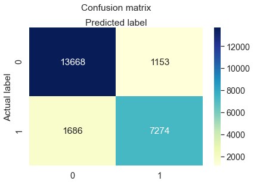

```python
# plot confusion matrix
class_names=[0,1] # name  of classes
fig, ax = plt.subplots()
tick_marks = np.arange(len(class_names))
plt.xticks(tick_marks, class_names)
plt.yticks(tick_marks, class_names)
# create heatmap
sns.heatmap(pd.DataFrame(cnf_matrix), annot=True, cmap="YlGnBu" ,fmt='g')
ax.xaxis.set_label_position("top")
plt.tight_layout()
plt.title('Confusion matrix', y=1.1)
plt.ylabel('Actual label')
plt.xlabel('Predicted label')
```

```python
print("Accuracy:",metrics.accuracy_score(test_y, y_pred_xgb))
print("Precision:",metrics.precision_score(test_y, y_pred_xgb))
print("Recall:",metrics.recall_score(test_y, y_pred_xgb))
```

```
Accuracy: 0.8806189815398848
Precision: 0.8631778806218109
Recall: 0.8118303571428571
```

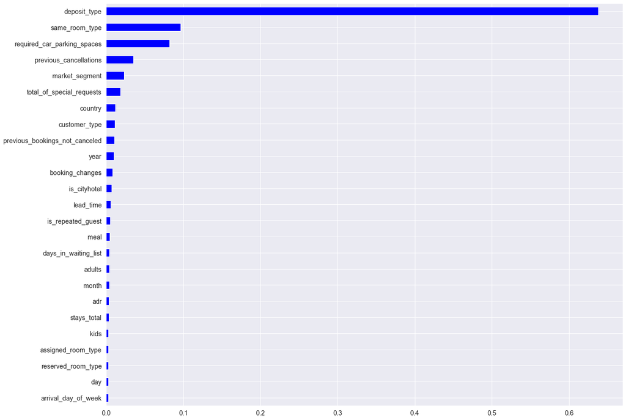

```python
# Create a pd.Series of features importances
importances_xgb = pd.Series(xgb.feature_importances_,
index = X.columns)
# Sort importances_xgb
sorted_importances_xgb = importances_xgb.sort_values()
# Make a horizontal bar plot
sorted_importances_xgb.plot(kind='barh', color='blue',figsize=(20,16))
plt.show()
```

```python
# another way of finding feature importance
xgb_feature_importances = pd.DataFrame(list(zip(train_X.columns.values,xgb.feature_importances_)),
                                       columns =['Feafure', 'Importance'])
xgb_feature_importances=xgb_feature_importances.sort_values(by=['Importance'], ascending=False)
```

```python
xgb_feature_importances
```

|  | Feafure | Importance |
| --- | --- | --- |
| 13 | deposit_type | 0.637900 |
| 22 | same_room_type | 0.096422 |
| 17 | required_car_parking_spaces | 0.081975 |
| 8 | previous_cancellations | 0.035162 |
| 6 | market_segment | 0.023077 |
| 18 | total_of_special_requests | 0.018214 |
| 5 | country | 0.011611 |
| 15 | customer_type | 0.011334 |
| 9 | previous_bookings_not_canceled | 0.010417 |
| 1 | year | 0.010160 |
| 12 | booking_changes | 0.008130 |
| 23 | is_cityhotel | 0.007120 |
| 0 | lead_time | 0.006159 |
| 7 | is_repeated_guest | 0.005066 |
| 4 | meal | 0.004495 |
| 14 | days_in_waiting_list | 0.004038 |
| 3 | adults | 0.003983 |
| 19 | month | 0.003790 |
| 16 | adr | 0.003539 |
| 20 | stays_total | 0.003427 |
| 21 | kids | 0.003005 |
| 11 | assigned_room_type | 0.002908 |
| 10 | reserved_room_type | 0.002781 |
| 2 | day | 0.002697 |
| 24 | arrival_day_of_week | 0.002590 |

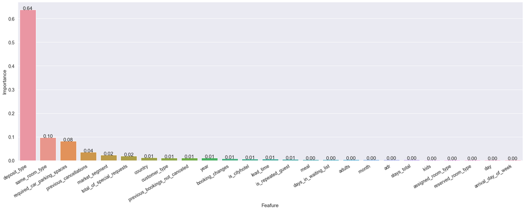

```python
# method 2 of plotting feature importance. This only acts as an alternative to put on the presentation slides
fig, ax = plt.subplots()
fig.set_size_inches(28, 10)
sns.set(font_scale = 1.3)
ax = sns.barplot(x="Feafure", y="Importance", data=xgb_feature_importances)
fig.autofmt_xdate()

from matplotlib import pyplot as plt
import numpy as np

def show_values_on_bars(axs):
    def _show_on_single_plot(ax):
        for p in ax.patches:
            _x = p.get_x() + p.get_width() / 2
            _y = p.get_y() + p.get_height()
            value = '{:.2f}'.format(p.get_height())
            ax.text(_x, _y, value, ha="center")

    if isinstance(axs, np.ndarray):
        for idx, ax in np.ndenumerate(axs):
            _show_on_single_plot(ax)
    else:
        _show_on_single_plot(axs)

show_values_on_bars(ax)
```

#### Voting Classifier

```python
#conda install -c anaconda py-xgboost
```

```python
from sklearn.linear_model import LogisticRegression
from sklearn.neighbors import KNeighborsClassifier
from sklearn import datasets
import numpy as np



# Set seed for reproducibility
SEED=1

# Logitstic Regression
logReg=LogisticRegression(solver='lbfgs', max_iter=4000)

# KNN
knn = KNeighborsClassifier(n_neighbors=2)

# Define the list classifiers
classifiers = [#('Logistics Regression', logReg),
               ('CatBoost', model_cb),
               ('Classification Tree', dt),
               #('Random Forest',rf),
               ('Gradient Boost', gb),
               ('XGBoost', xgb)]
```

```python
# Import accuracy_score
from sklearn.metrics import accuracy_score
for clf_name, clf in classifiers:

    # Fit clf to the training set
    clf.fit(train_X, train_y)

    # Predict y_pred
    y_pred = clf.predict(test_X)

    # Calculate accuracy
    accuracy = accuracy_score(test_y, y_pred)

    # Evaluate clf's accuracy on the test set
    print('{:s} : {:.3f}'.format(clf_name, accuracy))
```

[output not shown]

[output cut: 951 more lines]

```
990:	learn: 0.2446528	total: 16.3s	remaining: 148ms
991:	learn: 0.2446044	total: 16.3s	remaining: 131ms
992:	learn: 0.2445621	total: 16.3s	remaining: 115ms
993:	learn: 0.2444973	total: 16.3s	remaining: 98.6ms
994:	learn: 0.2444637	total: 16.4s	remaining: 82.2ms
995:	learn: 0.2444289	total: 16.4s	remaining: 65.8ms
996:	learn: 0.2444113	total: 16.4s	remaining: 49.3ms
997:	learn: 0.2443508	total: 16.4s	remaining: 32.9ms
998:	learn: 0.2443203	total: 16.4s	remaining: 16.4ms
999:	learn: 0.2442557	total: 16.4s	remaining: 0us
CatBoost : 0.878
Classification Tree : 0.829
Gradient Boost : 0.866
[09:05:36] WARNING: ..\src\learner.cc:1061: Starting in XGBoost 1.3.0, the default evaluation metric used with the objective 'binary:logistic' was changed from 'error' to 'logloss'. Explicitly set eval_metric if you'd like to restore the old behavior.
XGBoost : 0.881
```

```python
# Import VotingCLassifier from sklearn.ensemble
from sklearn.ensemble import VotingClassifier

# Instantiate a VotingClassifier vc
vc = VotingClassifier(estimators=classifiers, voting='hard')

# Fit vc to the training set
vc.fit(train_X, train_y)

# Evaluate the test set predictions
y_pred = vc.predict(test_X)

# Calculate accuracy score
accuracy = accuracy_score(test_y, y_pred)
```

[output not shown]

[output cut: 947 more lines]

[output not shown]

```python
print('Hard Voting Classifier: {:.3f}'.format(accuracy))
```

```
Hard Voting Classifier: 0.872
```

```python
# Import VotingCLassifier from sklearn.ensemble
from sklearn.ensemble import VotingClassifier

# Instantiate a VotingClassifier vc
vc = VotingClassifier(estimators=classifiers, voting='soft')

# Fit vc to the training set
vc.fit(train_X, train_y)

# Evaluate the test set predictions
y_pred = vc.predict(test_X)

# Calculate accuracy score
accuracy = accuracy_score(test_y, y_pred)
```

[output not shown]

[output cut: 947 more lines]

[output not shown]

```python
print('Soft Voting Classifier: {:.3f}'.format(accuracy))
```

```
Soft Voting Classifier: 0.876
```

```python
# Predict the labels of the training set
y_pred_train = vc.predict(train_X)

# Evaluate the training set RMSE of dt
acc_train = accuracy_score(train_y, y_pred_train)

# Print RMSE_train
print('Train set accuracy of dt: {:.2f}'.format(acc_train))
```

```
Train set accuracy of dt: 0.89
```

```python
import warnings
warnings.filterwarnings("ignore")
cv_results = cross_validate(vc, train_X, train_y, cv=5)
cv_results['test_score']
```

[output not shown]

[output cut: 4955 more lines]

[output not shown]

```
array([0.87358739, 0.87063709, 0.87216148, 0.87321278, 0.87615643])
```

```python
f"Cross Valiation accuracy: {round(sum(cv_results['test_score'])/5,2)}"
```

```
'Cross Valiation accuracy: 0.87'
```

```python
# print confusion matrix
from sklearn import metrics
cnf_matrix = metrics.confusion_matrix(test_y, y_pred)
cnf_matrix
```

```
array([[13748,  1073],
       [ 1864,  7096]], dtype=int64)
```

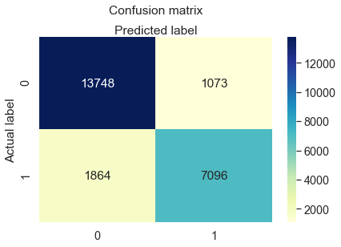

```python
# plot confusion matrix
class_names=[0,1] # name  of classes
fig, ax = plt.subplots()
tick_marks = np.arange(len(class_names))
plt.xticks(tick_marks, class_names)
plt.yticks(tick_marks, class_names)
# create heatmap
sns.heatmap(pd.DataFrame(cnf_matrix), annot=True, cmap="YlGnBu" ,fmt='g')
ax.xaxis.set_label_position("top")
plt.tight_layout()
plt.title('Confusion matrix', y=1.1)
plt.ylabel('Actual label')
plt.xlabel('Predicted label')
```

```python
print("Accuracy:",metrics.accuracy_score(test_y, y_pred))
print("Precision:",metrics.precision_score(test_y, y_pred))
print("Recall:",metrics.recall_score(test_y, y_pred))
```

```
Accuracy: 0.8764980446574997
Precision: 0.8686497735340923
Recall: 0.7919642857142857
```

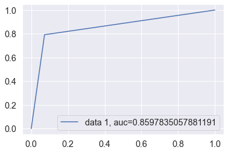

```python
# plot ROC curve with AUC score
fpr, tpr, _ = metrics.roc_curve(test_y,  y_pred)
auc = metrics.roc_auc_score(test_y,  y_pred)
plt.plot(fpr,tpr,label="data 1, auc="+str(auc))
plt.legend(loc=4)
plt.show()
```